# Lab 2 - Spatial Autocorrelation

Afroza Hossain Misty

February 10th, 2023

# Spatial Autocorrelation

```r
options(scipen = 999) # turn off scientific notation
library(pacman)
p_load(sf,
       spdep,
       tmap,
       tidycensus,
       ggplot2,
       dplyr)
```

# **Washington County, Oregon**

## Moran’s I Scatter plot

Moran’s I scatter plot represents the correlation between a variable and the spatial Lag of the same variable.

### Creating Census block group

```r
cbg <- tidycensus::get_acs(
  geography = 'block group',
  year = 2020,
  state = 'OR',
  county = c('Washington'), # This can include multiple counties!
  variables = c("mhi_" = 'B19049_001'), # This can include multiple variables! And we can rename them!!!
  geometry = TRUE,
  output = 'wide'
) %>%
  st_transform(3857) %>% # Project to something with better units (meters, in this case)
  filter(!sf::st_is_empty(.)) # Make sure we only have rows with geometries!
```

### Plotting data on a static map

```r
head(cbg)
```

```
## Simple feature collection with 6 features and 4 fields
## Geometry type: MULTIPOLYGON
## Dimension:     XY
## Bounding box:  xmin: -13705050 ymin: 5685369 xmax: -13664160 ymax: 5722421
## Projected CRS: WGS 84 / Pseudo-Mercator
##          GEOID                                                          NAME
## 1 410670335002    Block Group 2, Census Tract 335, Washington County, Oregon
## 2 410670314032 Block Group 2, Census Tract 314.03, Washington County, Oregon
## 3 410670316143 Block Group 3, Census Tract 316.14, Washington County, Oregon
## 4 410670332013 Block Group 3, Census Tract 332.01, Washington County, Oregon
## 5 410670308032 Block Group 2, Census Tract 308.03, Washington County, Oregon
## 6 410670304022 Block Group 2, Census Tract 304.02, Washington County, Oregon
##    mhi_E mhi_M                       geometry
## 1 101731 21725 MULTIPOLYGON (((-13705054 5...
## 2  64708 19208 MULTIPOLYGON (((-13673232 5...
## 3  59674 49058 MULTIPOLYGON (((-13680465 5...
## 4  38305 16102 MULTIPOLYGON (((-13703333 5...
## 5  41750 17369 MULTIPOLYGON (((-13669040 5...
## 6  58886  4284 MULTIPOLYGON (((-13665692 5...
```

```r
# mhi_E is our estimate, mhi_M is our margin of error!

# This is filling NA with 0 - not something you would usually do for a real-world analysis!!
cbg$mhi <- ifelse(is.na(cbg$mhi_E), 0 ,cbg$mhi_E)

tmap_mode('view')
```

```
## tmap mode set to interactive viewing
```

```r
orig_basemaps <- c("Esri.WorldGrayCanvas","OpenStreetMap","Esri.WorldTopoMap")

# Woah, we can change the default basemaps!!
tmap_options(basemaps = c("Esri.WorldTopoMap","Stamen.TonerLite","Esri.WorldImagery"))
tm_shape(cbg) +
  tm_polygons(
    id = "",
    title = "Median Household Income",
    col = c("Median Household Income:"="mhi_E"), # I'm looking for those Null values!
    palette = "RdYlGn", # Many options here, either custom of from Color Brewer
    alpha = 0.7, # Transparency
    border.col = "white", # Line/border color
    lwd = 0.6, # Line/border width
    style='cont', # Many options... quantile, standard deviation, equal interval...
    # Try to change style to 'cont'jenks and see what happens!
    contrast = c(0,1)
  )
```

[interactive chart not shown]

```r
tmap_options(basemaps = orig_basemaps)
```

### Creating a Lag

```r
cbg_nb <- spdep::poly2nb(pl = cbg, queen = TRUE) # Using Queen Contiguity
cbg_nb
```

```
## Neighbour list object:
## Number of regions: 382
## Number of nonzero links: 2398
## Percentage nonzero weights: 1.643321
## Average number of links: 6.277487
```

```r
# 1: figure out which row the non-connection row is:
bad_rows <- card(cbg_nb) == 0 # `card()` counts neighbors!
which(bad_rows) # which row is bad?
```

```
## integer(0)
```

```r
# 2: Remove that row from cbg"
cbg <- cbg[!bad_rows,]

# 3: Re-run our cbg_nb definition:
cbg_nb <- spdep::poly2nb(pl = cbg, queen = TRUE) # Using Queen Contiguity
cbg_nb
```

```
## Neighbour list object:
## Number of regions: 382
## Number of nonzero links: 2398
## Percentage nonzero weights: 1.643321
## Average number of links: 6.277487
```

```r
cbg_W <- spdep::nb2listw(
  neighbours = cbg_nb,
  style = "W", # Leave this as a default
  zero.policy = TRUE) # This will allow for our NA values
print(cbg_W,zero.policy = T) # Just prints it all nice!
```

```
## Characteristics of weights list object:
## Neighbour list object:
## Number of regions: 382
## Number of nonzero links: 2398
## Percentage nonzero weights: 1.643321
## Average number of links: 6.277487
##
## Weights style: W
## Weights constants summary:
##     n     nn  S0       S1     S2
## W 382 145924 382 128.3795 1572.5
```

```r
dnn <- spdep::dnearneigh(x = st_centroid(cbg),d1 = 0,d2 = 5000)
cbg_dnn_W <- spdep::nb2listw(neighbours = dnn,style = "W",zero.policy = T)

# if you wanted to use this, you'd have to re-subset cbg based on the results of `card()`!
print(cbg_dnn_W,zero.policy = TRUE)
```

```
## Characteristics of weights list object:
## Neighbour list object:
## Number of regions: 382
## Number of nonzero links: 13390
## Percentage nonzero weights: 9.176009
## Average number of links: 35.05236
## 17 regions with no links:
## 1 163 174 177 194 269 270 309 313 320 330 332 335 336 359 371 379
##
## Weights style: W
## Weights constants summary:
##     n     nn  S0       S1       S2
## W 365 133225 365 30.34429 1472.824
```

```r
# This is how easy it is to calculate spatial lag:
cbg$lag_mhi <- spdep::lag.listw(x = cbg_W, var = cbg$mhi, zero.policy = TRUE)
cbg$lag_dist_mhi <- spdep::lag.listw(x = cbg_dnn_W, var = cbg$mhi, zero.policy = TRUE)

tmap_mode('plot') # Switch back to static maps
```

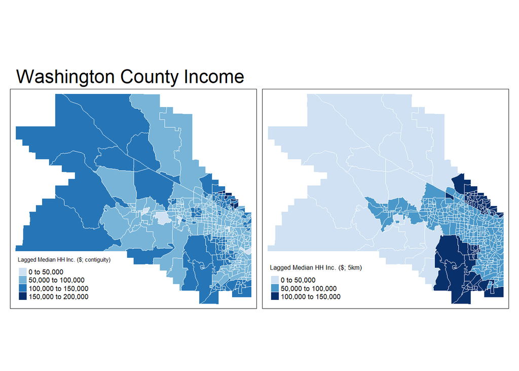

```r
# Woah, two maps in one graphic??
tm_shape(cbg) +
  tm_polygons(
    col = c('lag_mhi', 'lag_dist_mhi'),
    title = c('Lagged Median HH Inc. ($; contiguity)','Lagged Median HH Inc. ($; 5km)'),
    palette = "Blues",
    border.col = 'white',
    lwd = 0.5,
    contrast = c(0.2,1)
  ) +
  tm_layout(
    main.title = "Washington County Income",
    legend.position = c("left","bottom")
  )
```

### Creating Scatter Plot

```r
moran_plot = function(var, w_var, xlab, ylab, main_title = NULL, normalize = T){
  if(missing(main_title)){
    main_title = "Moran's I Plot"
  }
  if(normalize){
    var = scale(var) %>% as.vector
    w_var = scale(w_var) %>% as.vector()
  }
  plot_dat = data.frame(var,w_var,stringsAsFactors = F)
  plot_dat %>% ggplot() +
    geom_vline(xintercept = 0) +
    geom_hline(yintercept = 0) +
    geom_point(aes(x=var,y=w_var), color='grey35') +
    xlab(xlab) +
    ylab(ylab) +
    geom_smooth(
      mapping = aes(x=var,y=w_var),
      formula = 'y ~ x',
      method = 'lm',
      color="grey10",
      size=1,
      lty = 2,
      se=F) +
    scale_color_manual(
      name = "",
      values = c('HH'="firebrick",'HL'="brown1",'LL'="navy",'LH'="cornflowerblue")) +
    ggtitle(main_title)
}
```

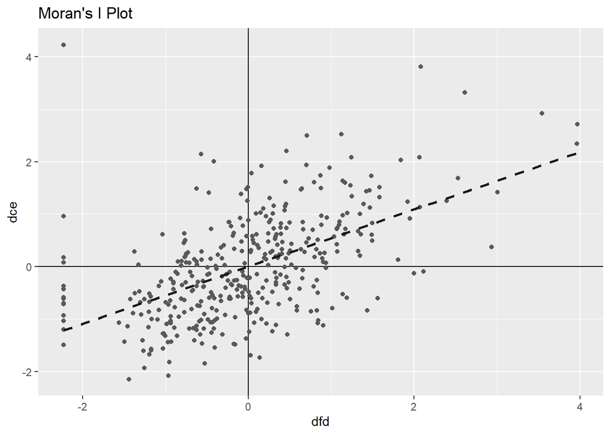

```r
moran_plot( var = cbg$mhi, w_var = cbg$lag_mhi, xlab = "dfd", ylab = "dce")
```

Conclusion: This scatter plot shows positive spatial correlation meaning that similar values of the variable, median household income, are located in the same geographical location.

# **Franklin County, Ohio**

As I said earlier my curiosity is to know about a place where I live or have lived, so I selected Franklin County as my next location to analyze the geographic pattern of household income within the county.

## Moran’s I Scatter Plot

### Creating Census block group

```r
cbg1 <- tidycensus::get_acs(
  geography = 'block group',
  year = 2020,
  state = 'OH',
  county = c('Franklin'), # This can include multiple counties!
  variables = c("mhi_" = 'B19049_001'), # This can include multiple variables! And we can rename them!!!
  geometry = TRUE,
  output = 'wide'
) %>%
  st_transform(3857) %>% # Project to something with better units (meters, in this case)
  filter(!sf::st_is_empty(.)) # Make sure we only have rows with geometries!
```

### Plotting data on a static map

```r
head(cbg1)
```

```
## Simple feature collection with 6 features and 4 fields
## Geometry type: MULTIPOLYGON
## Dimension:     XY
## Bounding box:  xmin: -9251770 ymin: 4849884 xmax: -9219320 ymax: 4885911
## Projected CRS: WGS 84 / Pseudo-Mercator
##          GEOID                                                     NAME  mhi_E
## 1 390490097113 Block Group 3, Census Tract 97.11, Franklin County, Ohio  40735
## 2 390490093942 Block Group 2, Census Tract 93.94, Franklin County, Ohio  73125
## 3 390490001104  Block Group 4, Census Tract 1.10, Franklin County, Ohio 228194
## 4 390490063011 Block Group 1, Census Tract 63.01, Franklin County, Ohio  48802
## 5 390490070411 Block Group 1, Census Tract 70.41, Franklin County, Ohio  74438
## 6 390490010005    Block Group 5, Census Tract 10, Franklin County, Ohio  89032
##    mhi_M                       geometry
## 1  21102 MULTIPOLYGON (((-9249085 48...
## 2  35349 MULTIPOLYGON (((-9220342 48...
## 3 105978 MULTIPOLYGON (((-9242845 48...
## 4  19806 MULTIPOLYGON (((-9251770 48...
## 5   8559 MULTIPOLYGON (((-9243426 48...
## 6  37778 MULTIPOLYGON (((-9240671 48...
```

```r
# mhi_E is our estimate, mhi_M is our margin of error!

# This is filling NA with 0 - not something you would usually do for a real-world analysis!!
cbg1$mhi <- ifelse(is.na(cbg1$mhi_E), 0 ,cbg1$mhi_E)

tmap_mode('view')
```

```
## tmap mode set to interactive viewing
```

```r
orig_basemaps <- c("Esri.WorldGrayCanvas","OpenStreetMap","Esri.WorldTopoMap")

# Woah, we can change the default basemaps!!
tmap_options(basemaps = c("Esri.WorldTopoMap","Stamen.TonerLite","Esri.WorldImagery"))
tm_shape(cbg1) +
  tm_polygons(
    id = "",
    title = "Median Household Income",
    col = c("Median Household Income:"="mhi_E"), # I'm looking for those Null values!
    palette = "RdYlGn", # Many options here, either custom of from Color Brewer
    alpha = 0.7, # Transparency
    border.col = "white", # Line/border color
    lwd = 0.6, # Line/border width
    style='cont', # Many options... quantile, standard deviation, equal interval...
    # Try to change style to 'cont'jenks and see what happens!
    contrast = c(0,1)
  )
```

[interactive chart not shown]

```r
tmap_options(basemaps = orig_basemaps)
# Want to see the available basemaps? Check this:
# leaflet::providers
# Want to see Color Brewer palettes? Run this and see what happens:
# RColorBrewer::display.brewer.all()
```

### Creating a Lag

```r
cbg1_nb <- spdep::poly2nb(pl = cbg1, queen = TRUE) # Using Queen Contiguity
cbg1_nb
```

```
## Neighbour list object:
## Number of regions: 952
## Number of nonzero links: 5920
## Percentage nonzero weights: 0.6532025
## Average number of links: 6.218487
```

```r
# 1: figure out which row the non-connection row is:
bad_rows <- card(cbg1_nb) == 0 # `card()` counts neighbors!
which(bad_rows) # which row is bad?
```

```
## integer(0)
```

```r
# 2: Remove that row from cbg"
cbg1 <- cbg1[!bad_rows,]

# 3: Re-run our cbg_nb definition:
cbg1_nb <- spdep::poly2nb(pl = cbg1, queen = TRUE) # Using Queen Contiguity
cbg1_nb
```

```
## Neighbour list object:
## Number of regions: 952
## Number of nonzero links: 5920
## Percentage nonzero weights: 0.6532025
## Average number of links: 6.218487
```

```r
cbg1_W <- spdep::nb2listw(
  neighbours = cbg1_nb,
  style = "W", # Leave this as a default
  zero.policy = TRUE) # This will allow for our NA values
print(cbg1_W,zero.policy = T) # Just prints it all nice!
```

```
## Characteristics of weights list object:
## Neighbour list object:
## Number of regions: 952
## Number of nonzero links: 5920
## Percentage nonzero weights: 0.6532025
## Average number of links: 6.218487
##
## Weights style: W
## Weights constants summary:
##     n     nn  S0       S1       S2
## W 952 906304 952 324.6097 3943.956
```

```r
dnn <- spdep::dnearneigh(x = st_centroid(cbg1),d1 = 0,d2 = 5000)
cbg1_dnn_W <- spdep::nb2listw(neighbours = dnn,style = "W",zero.policy = T)

# if you wanted to use this, you'd have to re-subset cbg based on the results of `card()`!
print(cbg1_dnn_W,zero.policy = TRUE)
```

```
## Characteristics of weights list object:
## Neighbour list object:
## Number of regions: 952
## Number of nonzero links: 49524
## Percentage nonzero weights: 5.464392
## Average number of links: 52.02101
## 2 regions with no links:
## 397 491
##
## Weights style: W
## Weights constants summary:
##     n     nn  S0       S1       S2
## W 950 902500 950 60.31652 3817.686
```

```r
# This is how easy it is to calculate spatial lag:
cbg1$lag_mhi <- spdep::lag.listw(x = cbg1_W, var = cbg1$mhi, zero.policy = TRUE)
cbg1$lag_dist_mhi <- spdep::lag.listw(x = cbg1_dnn_W, var = cbg1$mhi, zero.policy = TRUE)

tmap_mode('plot') # Switch back to static maps
```

[figure not shown]

```r
# Woah, two maps in one graphic??
tm_shape(cbg1) +
  tm_polygons(
    col = c('lag_mhi', 'lag_dist_mhi'),
    title = c('Lagged Median HH Inc. ($; contiguity)','Lagged Median HH Inc. ($; 5km)'),
    palette = "BuPu",
    border.col = 'white',
    lwd = 0.5,
    contrast = c(0.2,1)
  ) +
  tm_layout(
    main.title = "Washington County Income",
    legend.position = c("left","bottom")
  )
```

### Creating Scatter Plot

```r
moran_plot = function(var, w_var, xlab, ylab, main_title = NULL, normalize = T){
  if(missing(main_title)){
    main_title = "Moran's I Plot"
  }
  if(normalize){
    var = scale(var) %>% as.vector
    w_var = scale(w_var) %>% as.vector()
  }
  plot_dat = data.frame(var,w_var,stringsAsFactors = F)
  plot_dat %>% ggplot() +
    geom_vline(xintercept = 0) +
    geom_hline(yintercept = 0) +
    geom_point(aes(x=var,y=w_var), color='grey35') +
    xlab(xlab) +
    ylab(ylab) +
    geom_smooth(
      mapping = aes(x=var,y=w_var),
      formula = 'y ~ x',
      method = 'lm',
      color="grey10",
      size=1,
      lty = 2,
      se=F) +
    scale_color_manual(
      name = "",
      values = c('HH'="firebrick",'HL'="brown1",'LL'="navy",'LH'="cornflowerblue")) +
    ggtitle(main_title)
}
```

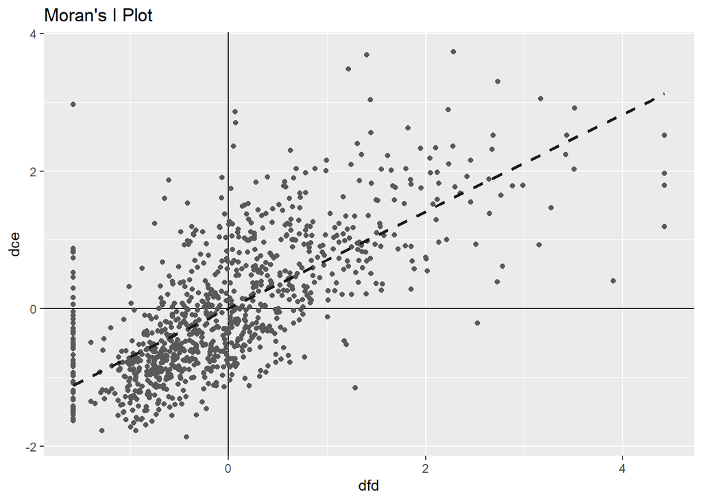

```r
moran_plot( var = cbg1$mhi, w_var = cbg1$lag_mhi, xlab = "dfd", ylab = "dce")
```

Conclusion: The line moves up which means people with the same income also tend to be closer to people at their same income level. So, this plot represents positive spatial correlation.

## Global Moran’s I

```r
c_test <- spdep::moran.mc(cbg$mhi, listw = cbg_W, nsim = 999, zero.policy = TRUE)
c_test
```

```
##
##  Monte-Carlo simulation of Moran I
##
## data:  cbg$mhi
## weights: cbg_W
## number of simulations + 1: 1000
##
## statistic = 0.32751, observed rank = 1000, p-value = 0.001
## alternative hypothesis: greater
```

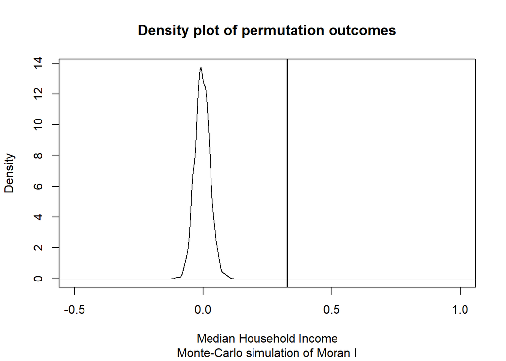

```r
plot(c_test,xlim=c(-0.5,1.0),xlab="Median Household Income")
```

Conclusion: In this density plot, the p-value is 0.001 < 0.5 considered as statistically significant. So here, we reject the null hypothesis.

## Geris-Ord G

```r
knitr::opts_chunk$set(echo = FALSE)
g_test <- spdep::globalG.test(x = cbg1$mhi, listw = cbg1_W)
g_test
```

```
##
##  Getis-Ord global G statistic
##
## data:  cbg1$mhi
## weights: cbg1_W
##
## standard deviate = 18.973, p-value < 0.00000000000000022
## alternative hypothesis: greater
## sample estimates:
## Global G statistic        Expectation           Variance
## 0.0012680318333870 0.0010515247108307 0.0000000001302176
```

Conclusion: In this Geris-Ord G analysis, the Global G statistics value is greater than the expectation value suggesting that there are potential hot spots in the data. Moreover, the p-value of this permutation is less than 0.05 also representing high values spatially clustered with each other.

# **Portland, Oregon**

## Moran’s I Scatter Plot

### Creating Census block group

### Plotting data on a static map

```
## Simple feature collection with 6 features and 21 fields
## Geometry type: POLYGON
## Dimension:     XY
## Bounding box:  xmin: -122.8285 ymin: 45.48826 xmax: -122.7938 ymax: 45.53104
## Geodetic CRS:  NAD83
##          GEOID poor_eng ovr_65 und_18 pov_05 pov_1 no_hs   poc iso_eld   mhh
## 1 410670314043    10.17  10.79  25.96   9.32 20.11 16.10 36.90    4.93 54531
## 2 410670314021    22.57   2.70  20.66  20.39 27.63 16.25 40.92    0.59 31359
## 3 410670314042     0.00  13.81  25.69   0.00  0.84  7.80  4.20    0.72 86711
## 4 410670314041     2.07  14.93  16.62   1.25  2.01 13.43 13.05    4.64 70266
## 5 410670314044     0.00  10.42  20.93  11.23 30.46 10.33  6.11    3.32 59375
## 6 410670315083     3.32  22.69  13.47   1.55 10.47  8.08  9.33   10.47 34844
##   pop_15     no2   uhi_a   uhi_b   uhi_c ls_den ls_100 ls_500 fire_den
## 1   1298  9.3360 17.6863 34.0223 30.7441      0   0.86   0.23        0
## 2   1520  9.4360 18.2085 34.2717 30.9635      0  10.39   1.62        0
## 3    833  9.7163 17.2407 33.6836 31.1268      0   0.00   0.00        0
## 4   1594 11.1393 17.2122 33.8198 31.0286      0   0.01   0.00        0
## 5   1113  8.9984 16.9409 33.6073 31.2247      0   0.77   0.67        0
## 6    965  9.2458 17.8279 34.0549 30.8327      0   2.22   0.14        0
##   lag_pov_1      can                       geometry
## 1 16.298571 15.24528 POLYGON ((-122.8232 45.5095...
## 2 22.126667 11.72190 POLYGON ((-122.8285 45.5001...
## 3 14.436667 23.02203 POLYGON ((-122.809 45.503, ...
## 4 11.688571 28.81579 POLYGON ((-122.8045 45.5133...
## 5  7.002500 19.22804 POLYGON ((-122.8198 45.5082...
## 6  7.115714 17.70947 POLYGON ((-122.8068 45.5310...
```

```
## tmap mode set to interactive viewing
```

[interactive chart not shown]

### Creating a Lag

```
## Neighbour list object:
## Number of regions: 913
## Number of nonzero links: 5676
## Percentage nonzero weights: 0.6809274
## Average number of links: 6.216867
```

```
## integer(0)
```

```
## Neighbour list object:
## Number of regions: 913
## Number of nonzero links: 5676
## Percentage nonzero weights: 0.6809274
## Average number of links: 6.216867
```

```
## Characteristics of weights list object:
## Neighbour list object:
## Number of regions: 913
## Number of nonzero links: 5676
## Percentage nonzero weights: 0.6809274
## Average number of links: 6.216867
##
## Weights style: W
## Weights constants summary:
##     n     nn  S0       S1       S2
## W 913 833569 913 314.1867 3750.988
```

```
## Characteristics of weights list object:
## Neighbour list object:
## Number of regions: 913
## Number of nonzero links: 832656
## Percentage nonzero weights: 99.89047
## Average number of links: 912
##
## Weights style: W
## Weights constants summary:
##     n     nn  S0       S1   S2
## W 913 833569 913 2.002193 3652
```

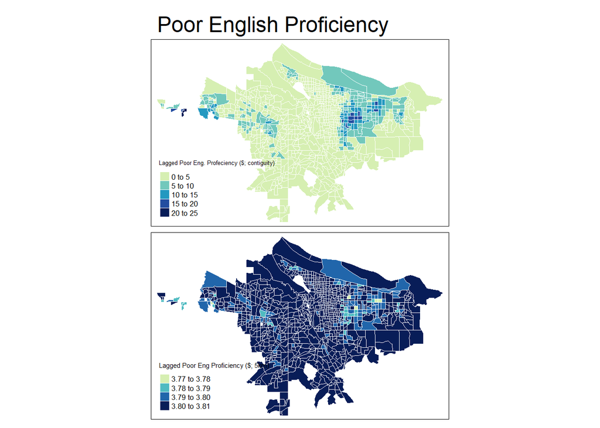

### Creating Scatter Plot

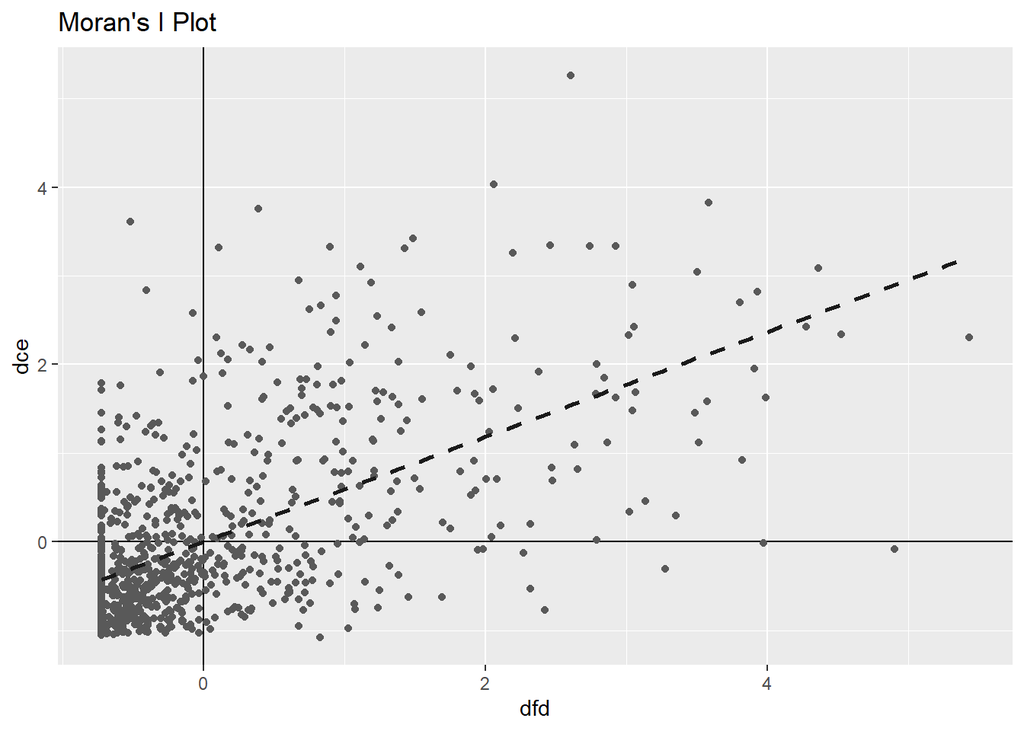

Conclusion: This scatter plot shows positive spatial correlation meaning that similar values of the variable, poor proficiency in English, are located in similar geographic locations.

## Geary-Ord G

```
##
##  Getis-Ord global G statistic
##
## data:  cbg2$poor_eng
## weights: cbg2_W
##
## standard deviate = 19.559, p-value < 0.00000000000000022
## alternative hypothesis: greater
## sample estimates:
## Global G statistic        Expectation           Variance
##  0.001948390507811  0.001096491228070  0.000000001897003
```

Conclusion: Here too the value of the Global G statistic is higher than the expected value suggesting that there are potential hot spots in the data. Furthermore, the p-value of this transition is less than 0.05 which also represents the high values clustered spatially with each other.

```
##
##  Monte-Carlo simulation of Moran I
##
## data:  cbg2$poor_eng
## weights: cbg2_W
## number of simulations + 1: 1000
##
## statistic = 0.40204, observed rank = 1000, p-value = 0.001
## alternative hypothesis: greater
```

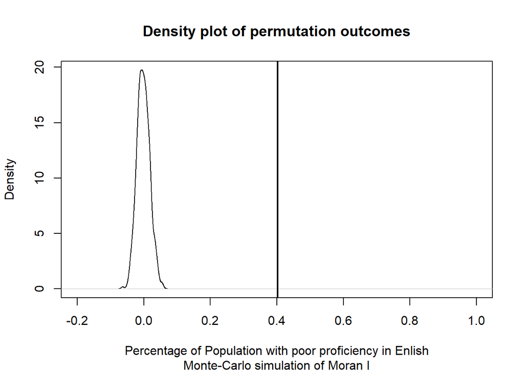

Conclusion: In this density plot, the p-value is 0.001 < 0.5 is considered statistically significant. So here, we reject the null hypothesis.